# PS270 Final Project

Maggie McEllistrem

## Project thoughts

I am interested in exploring data related to the difference presidents influence has on the economy. Each president has different implementations that they make during their term and I think gathering data based on the success of each president during there term would be very interesting to compare.

```r
library(readr)
```

How does each president have a negative or positive impact on the economy during their presidency?Typically a republican president would be assumed to make the economy more successful rather than a democratic president. Republican presidents focus more on businesses, deregulation within businesses, tax reduction and energy affordability. These traits of a typical republican president would likely boost the success of the economy. The explanatory variables are whether there was a republican president in a given year. I will measure their economic success within their presidential terms. The economic success during the term. This will be measured by GDP, unemployment rate, inflation rate, misery index, stock market performance, national debt. Greater economic success during the Reagan and G.W Bush administrations would prove my thesis correct while greater success within the economy during the Clinton, and Carter administrations would prove that my hypothesis is wrong.

```r
my_data <- read_delim("gdpv6.txt")
head(my_data)
```

```
## # A tibble: 6 × 8
##   statenum stateid  year     pop  realgdp rgdppc cgdppc origin
##      <dbl> <chr>   <dbl>   <dbl>    <dbl>  <dbl>  <dbl>  <dbl>
## 1        2 USA      1950 155547. 1987356. 12777.  1873.      0
## 2        2 USA      1951 158210. 2123564. 13422.  2109.      0
## 3        2 USA      1952 160943. 2191430. 13616.  2176.      0
## 4        2 USA      1953 163630. 2288842  13988.  2262.      0
## 5        2 USA      1954 166534. 2286074  13727.  2241.      0
## 6        2 USA      1955 169501. 2463346. 14533.  2413.      0
```

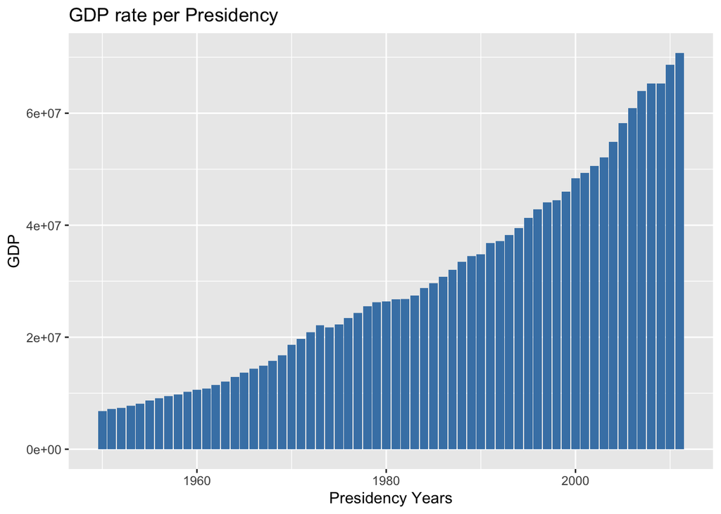

```r
library(ggplot2)
my_data |>
  ggplot(mapping = aes(x = year, y = realgdp)) +
  geom_col(fill = "steelblue") +
  labs(y = "GDP",
       x = "Presidency Years",
       title = "GDP rate per Presidency")
```

```r
gdp_fit <- lm(`realgdp` ~ year, data = my_data)
gdp_fit
```

```
##
## Call:
## lm(formula = realgdp ~ year, data = my_data)
##
## Coefficients:
## (Intercept)         year
##    -8493056         4377
```